# Laboratory of data visualization: Python project

Student: Marc Palomer

NIUB: 20118394

First of all, we are going to read all the information from different hospitals, which of course will be received in different format data sheets. We will need to read this formats, homogenize them into pandas' DataFrames, give them variable names and categorize the data depending on its procedence.

```python
#Import the needed libraries
import tabula as t
import pandas as p

# Read pdf, excel and csv into a DataFrame
LB = t.read_pdf("LongBeachData.pdf", pages='all',multiple_tables= False)
L = p.DataFrame(LB[0])
Clev = p.read_csv("processed.cleveland.data")
H = p.read_excel("Hungarian_Switzerland.xlsx",sheet_name = "Hungarian Data")
S = p.read_excel("Hungarian_Switzerland.xlsx",sheet_name = "Switzerland Data")


#We add a parient number to identify which patient we are talking about inside every hospital.
#After prior observation we can see Cleveland is the only dataset without this info.
num = []
for element in range (1,len(Clev)+1):
    num.append("Patient "+ str(element))
if Clev.columns[0] != "Patient num":
    Clev.insert(0,"Patient num",num)

#We change the names of the variables in order to homogenise them (prior checking all follow the same order in the datasets)
variables = ['Patient num','age','sex','cp','trestbps','chol','fbs','restecg','thalach','exang','oldpeak',
          'slope','ca','thal','num']
Clev.columns = variables
H.columns = variables
S.columns = variables
L.columns = variables

#We insert the Hospital column at the last variable position with its categorical value
Clev['Hospital']='CLE'
H['Hospital']='Hun'
S['Hospital']='Switz'
L['Hospital']='Long'

#We reorganize the columns as we wish
Clev=Clev.reindex(columns=['Patient num','age','sex','cp','trestbps','chol','fbs','restecg','thalach','exang','oldpeak',
          'slope','ca','thal','Hospital','num'])
L=L.reindex(columns=['Patient num','age','sex','cp','trestbps','chol','fbs','restecg','thalach','exang','oldpeak',
          'slope','ca','thal','Hospital','num'])
S=S.reindex(columns=['Patient num','age','sex','cp','trestbps','chol','fbs','restecg','thalach','exang','oldpeak',
          'slope','ca','thal','Hospital','num'])
H=H.reindex(columns=['Patient num','age','sex','cp','trestbps','chol','fbs','restecg','thalach','exang','oldpeak',
          'slope','ca','thal','Hospital','num'])
```

### Concatenating the datasets from the four hospitals

```python
#We concatenate the four Dataframes into a big one
C = p.concat([H, S, L, Clev], axis = 0, ignore_index=True)


print("\n if we don't take into consideration the 'Patient num' and the 'num', we have "+str(len(C.columns)-2)+" variables")
```

```
 if we don't take into consideration the 'Patient num' and the 'num', we have 14 variables
```

### Handling 'incorrect' or 'incomplete' data

If hospital is not CLE the ca variable is registered esporadically. All elements of 'ca' not in CLE will be converted to NaN

```python
from numpy import *
for idx, ele in enumerate(C['Hospital']):
    if ele != 'CLE':
        C.loc[[idx],['ca']] = nan #We look up the dataframe as it it was a matrix but using loc() property
```

### Cleaning missing values

Now we must change all the uninformative symbols for others we can handle, *?* --> *Nan*

```python
C = C.replace('?', nan)
m = input("If you wish to check if the replacement was correctly performed write Y")
if m == "Y":
    for element in C.columns:
        print("Variable: "+element)
        print(C[element].value_counts(dropna=False))
        print("\n")
#Here we can observe the amount of each observation we have divided by variables
#We can see the interrogants have been correctly replaced by NANs
```

### Data type handling

Now we are going to check the different types of data we are working with:

```python
def Data_Type(array):
    data_type = []
    for element in array:
        if type(element) not in data_type:
            data_type.append(type(element))
    return data_type

for element in C:
    data=Data_Type(C[str(element)])
    print(element, "; ", data)
```

```
Patient num ;  [<class 'str'>]
age ;  [<class 'float'>]
sex ;  [<class 'float'>]
cp ;  [<class 'float'>]
trestbps ;  [<class 'int'>, <class 'float'>, <class 'str'>]
chol ;  [<class 'int'>, <class 'float'>, <class 'str'>]
fbs ;  [<class 'int'>, <class 'float'>, <class 'str'>]
restecg ;  [<class 'float'>]
thalach ;  [<class 'int'>, <class 'float'>, <class 'str'>]
exang ;  [<class 'int'>, <class 'float'>, <class 'str'>]
oldpeak ;  [<class 'float'>, <class 'str'>, <class 'int'>]
slope ;  [<class 'float'>, <class 'int'>, <class 'str'>]
ca ;  [<class 'float'>, <class 'str'>]
thal ;  [<class 'float'>, <class 'int'>, <class 'str'>]
Hospital ;  [<class 'str'>]
num ;  [<class 'int'>]
```

As seen above, we have some datatypes inside some of our variables that don't match with what it should be, it is necessary to homogenize the data types into the correct ones.

```python
#Function to_numeric transforms the fata into float in our case
for el in variables:
    C[el]=p.to_numeric(C[el], downcast = 'float', errors = 'ignore')

#We check if now the datatypes are correct. They are.
for element in C:
    data=Data_Type(C[str(element)])
    print(element, "; ", data)
```

```
Patient num ;  [<class 'str'>]
age ;  [<class 'float'>]
sex ;  [<class 'float'>]
cp ;  [<class 'float'>]
trestbps ;  [<class 'float'>]
chol ;  [<class 'float'>]
fbs ;  [<class 'float'>]
restecg ;  [<class 'float'>]
thalach ;  [<class 'float'>]
exang ;  [<class 'float'>]
oldpeak ;  [<class 'float'>]
slope ;  [<class 'float'>]
ca ;  [<class 'float'>]
thal ;  [<class 'float'>]
Hospital ;  [<class 'str'>]
num ;  [<class 'float'>]
```

### Preliminary correlation visualization

```python
(C.corr()).style.background_gradient(cmap='coolwarm')
```

|  | age | sex | cp | trestbps | chol | fbs | restecg | thalach | exang | oldpeak | slope | ca | thal | num |
| --- | --- | --- | --- | --- | --- | --- | --- | --- | --- | --- | --- | --- | --- | --- |
| age | 1.000000 | 0.056362 | 0.169530 | 0.243648 | -0.086633 | 0.231853 | 0.211280 | -0.366646 | 0.202802 | 0.257062 | 0.152616 | 0.365732 | 0.136450 | 0.340880 |
| sex | 0.056362 | 1.000000 | 0.172326 | 0.000666 | -0.197499 | 0.088036 | -0.016620 | -0.179671 | 0.182011 | 0.103230 | 0.123866 | 0.095014 | 0.373528 | 0.259977 |
| cp | 0.169530 | 0.172326 | 1.000000 | 0.027071 | -0.132187 | 0.046494 | 0.035859 | -0.349075 | 0.418722 | 0.249027 | 0.213648 | 0.229952 | 0.318350 | 0.397031 |
| trestbps | 0.243648 | 0.000666 | 0.027071 | 1.000000 | 0.092641 | 0.158838 | 0.097695 | -0.105315 | 0.153050 | 0.161074 | 0.061430 | 0.100775 | 0.106890 | 0.123051 |
| chol | -0.086633 | -0.197499 | -0.132187 | 0.092641 | 1.000000 | 0.024479 | 0.116103 | 0.235992 | -0.034279 | 0.047327 | -0.060602 | 0.118462 | -0.180299 | -0.231357 |
| fbs | 0.231853 | 0.088036 | 0.046494 | 0.158838 | 0.024479 | 1.000000 | 0.128458 | -0.054939 | 0.031773 | 0.051465 | 0.084172 | 0.152906 | 0.103808 | 0.158310 |
| restecg | 0.211280 | -0.016620 | 0.035859 | 0.097695 | 0.116103 | 0.128458 | 1.000000 | 0.052253 | 0.034009 | 0.115988 | -0.019782 | 0.131116 | -0.041551 | 0.142026 |
| thalach | -0.366646 | -0.179671 | -0.349075 | -0.105315 | 0.235992 | -0.054939 | 0.052253 | 1.000000 | -0.356174 | -0.152076 | -0.363476 | -0.264423 | -0.327854 | -0.365992 |
| exang | 0.202802 | 0.182011 | 0.418722 | 0.153050 | -0.034279 | 0.031773 | 0.034009 | -0.356174 | 1.000000 | 0.394245 | 0.323877 | 0.144129 | 0.341977 | 0.387921 |
| oldpeak | 0.257062 | 0.103230 | 0.249027 | 0.161074 | 0.047327 | 0.051465 | 0.115988 | -0.152076 | 0.394245 | 1.000000 | 0.419669 | 0.299260 | 0.253504 | 0.445021 |
| slope | 0.152616 | 0.123866 | 0.213648 | 0.061430 | -0.060602 | 0.084172 | -0.019782 | -0.363476 | 0.323877 | 0.419669 | 1.000000 | 0.116697 | 0.289363 | 0.309374 |
| ca | 0.365732 | 0.095014 | 0.229952 | 0.100775 | 0.118462 | 0.152906 | 0.131116 | -0.264423 | 0.144129 | 0.299260 | 0.116697 | 1.000000 | 0.258398 | 0.518018 |
| thal | 0.136450 | 0.373528 | 0.318350 | 0.106890 | -0.180299 | 0.103808 | -0.041551 | -0.327854 | 0.341977 | 0.253504 | 0.289363 | 0.258398 | 1.000000 | 0.441990 |
| num | 0.340880 | 0.259977 | 0.397031 | 0.123051 | -0.231357 | 0.158310 | 0.142026 | -0.365992 | 0.387921 | 0.445021 | 0.309374 | 0.518018 | 0.441990 | 1.000000 |

### Filtering patients by different factors

Use factors to filter patients (rows): Hospital, sex, age. Prior preliminary checking of correlations has been done, but as it occupies a lot of visual space it won't be shown explicitly.

```python
#Filtering by age

above_65=C[C['age']>=65]
corr_above_65=above_65.corr()
corr_above_65.style.background_gradient(cmap='coolwarm')
```

|  | age | sex | cp | trestbps | chol | fbs | restecg | thalach | exang | oldpeak | slope | ca | thal | num |
| --- | --- | --- | --- | --- | --- | --- | --- | --- | --- | --- | --- | --- | --- | --- |
| age | 1.000000 | 0.033325 | -0.074838 | -0.011196 | -0.048274 | 0.026610 | 0.000537 | -0.126190 | 0.089905 | 0.109849 | 0.104141 | 0.084174 | -0.134184 | 0.100739 |
| sex | 0.033325 | 1.000000 | 0.221611 | -0.033602 | -0.210002 | 0.160525 | -0.051217 | -0.233665 | 0.338841 | 0.193855 | 0.261174 | 0.161065 | 0.442694 | 0.394314 |
| cp | -0.074838 | 0.221611 | 1.000000 | -0.133561 | -0.110416 | -0.062330 | -0.076772 | -0.211765 | 0.344061 | 0.118175 | 0.164758 | 0.141578 | 0.475168 | 0.339720 |
| trestbps | -0.011196 | -0.033602 | -0.133561 | 1.000000 | -0.016634 | 0.256778 | -0.118766 | 0.063094 | 0.033354 | 0.095522 | 0.129808 | -0.020129 | 0.148726 | 0.054447 |
| chol | -0.048274 | -0.210002 | -0.110416 | -0.016634 | 1.000000 | 0.059616 | 0.234163 | 0.278992 | 0.098509 | 0.062056 | -0.014021 | 0.032136 | -0.313221 | -0.087734 |
| fbs | 0.026610 | 0.160525 | -0.062330 | 0.256778 | 0.059616 | 1.000000 | -0.045962 | 0.040322 | -0.002564 | -0.054152 | 0.165247 | 0.047607 | 0.189778 | 0.072373 |
| restecg | 0.000537 | -0.051217 | -0.076772 | -0.118766 | 0.234163 | -0.045962 | 1.000000 | 0.096373 | -0.133937 | -0.103108 | -0.097562 | 0.042981 | -0.221748 | -0.068336 |
| thalach | -0.126190 | -0.233665 | -0.211765 | 0.063094 | 0.278992 | 0.040322 | 0.096373 | 1.000000 | -0.269099 | -0.017796 | -0.300428 | 0.032491 | -0.175721 | -0.162900 |
| exang | 0.089905 | 0.338841 | 0.344061 | 0.033354 | 0.098509 | -0.002564 | -0.133937 | -0.269099 | 1.000000 | 0.152470 | 0.302040 | 0.276778 | 0.262371 | 0.446374 |
| oldpeak | 0.109849 | 0.193855 | 0.118175 | 0.095522 | 0.062056 | -0.054152 | -0.103108 | -0.017796 | 0.152470 | 1.000000 | 0.525121 | -0.021557 | 0.268021 | 0.353450 |
| slope | 0.104141 | 0.261174 | 0.164758 | 0.129808 | -0.014021 | 0.165247 | -0.097562 | -0.300428 | 0.302040 | 0.525121 | 1.000000 | -0.038112 | 0.327551 | 0.395138 |
| ca | 0.084174 | 0.161065 | 0.141578 | -0.020129 | 0.032136 | 0.047607 | 0.042981 | 0.032491 | 0.276778 | -0.021557 | -0.038112 | 1.000000 | 0.101654 | 0.443672 |
| thal | -0.134184 | 0.442694 | 0.475168 | 0.148726 | -0.313221 | 0.189778 | -0.221748 | -0.175721 | 0.262371 | 0.268021 | 0.327551 | 0.101654 | 1.000000 | 0.479300 |
| num | 0.100739 | 0.394314 | 0.339720 | 0.054447 | -0.087734 | 0.072373 | -0.068336 | -0.162900 | 0.446374 | 0.353450 | 0.395138 | 0.443672 | 0.479300 | 1.000000 |

```python
C_CLE=C[C['Hospital'] == "CLE"]
C_S=C[C['Hospital'] == "Switz"]
C_L=C[C['Hospital'] == "Long"]
C_H=C[C['Hospital'] == "Hun"]

#We observe the maximum and minimum ages for further segmentation
maxi = (C['age'].max())
mini = (C['age'].min())
print('The ages are between '+str(mini)+' and '+str(maxi))
```

```
The ages are between 28.0 and 77.0
```

```python
#Filtering by sex
n = 0
while n == 0:
    gender = input('Insert 0 for male and 1 for female correlation table')
    if gender == str(1) or gender == str(0):
        n = n+1

corr = C[C['sex']== int(gender)]
(corr.corr()).style.background_gradient(cmap='coolwarm')
```

|  | age | sex | cp | trestbps | chol | fbs | restecg | thalach | exang | oldpeak | slope | ca | thal | num |
| --- | --- | --- | --- | --- | --- | --- | --- | --- | --- | --- | --- | --- | --- | --- |
| age | 1.000000 | nan | 0.155178 | 0.317277 | 0.134045 | 0.158147 | 0.181860 | -0.302742 | 0.138253 | 0.237970 | 0.067830 | 0.388285 | 0.099994 | 0.253078 |
| sex | nan | nan | nan | nan | nan | nan | nan | nan | nan | nan | nan | nan | nan | nan |
| cp | 0.155178 | nan | 1.000000 | 0.097650 | -0.023830 | 0.043408 | 0.168247 | -0.217160 | 0.400194 | 0.313222 | 0.270557 | 0.141782 | 0.237156 | 0.400117 |
| trestbps | 0.317277 | nan | 0.097650 | 1.000000 | 0.079986 | 0.103380 | 0.063181 | -0.095607 | 0.277986 | 0.239406 | 0.172446 | 0.276674 | 0.295658 | 0.355919 |
| chol | 0.134045 | nan | -0.023830 | 0.079986 | 1.000000 | 0.168783 | 0.274548 | 0.018629 | 0.077453 | 0.067027 | -0.108465 | 0.094507 | 0.203160 | -0.080600 |
| fbs | 0.158147 | nan | 0.043408 | 0.103380 | 0.168783 | 1.000000 | 0.179897 | -0.101728 | 0.116099 | 0.080346 | -0.069890 | 0.266756 | 0.150283 | 0.223980 |
| restecg | 0.181860 | nan | 0.168247 | 0.063181 | 0.274548 | 0.179897 | 1.000000 | 0.068474 | 0.027939 | 0.194209 | 0.046251 | 0.098204 | 0.044779 | 0.175387 |
| thalach | -0.302742 | nan | -0.217160 | -0.095607 | 0.018629 | -0.101728 | 0.068474 | 1.000000 | -0.223801 | -0.151526 | -0.323480 | -0.147917 | -0.339408 | -0.166787 |
| exang | 0.138253 | nan | 0.400194 | 0.277986 | 0.077453 | 0.116099 | 0.027939 | -0.223801 | 1.000000 | 0.284109 | 0.315257 | 0.027597 | 0.382908 | 0.332382 |
| oldpeak | 0.237970 | nan | 0.313222 | 0.239406 | 0.067027 | 0.080346 | 0.194209 | -0.151526 | 0.284109 | 1.000000 | 0.494234 | 0.464330 | 0.383266 | 0.559184 |
| slope | 0.067830 | nan | 0.270557 | 0.172446 | -0.108465 | -0.069890 | 0.046251 | -0.323480 | 0.315257 | 0.494234 | 1.000000 | 0.198823 | 0.385770 | 0.392011 |
| ca | 0.388285 | nan | 0.141782 | 0.276674 | 0.094507 | 0.266756 | 0.098204 | -0.147917 | 0.027597 | 0.464330 | 0.198823 | 1.000000 | 0.381585 | 0.644481 |
| thal | 0.099994 | nan | 0.237156 | 0.295658 | 0.203160 | 0.150283 | 0.044779 | -0.339408 | 0.382908 | 0.383266 | 0.385770 | 0.381585 | 1.000000 | 0.565168 |
| num | 0.253078 | nan | 0.400117 | 0.355919 | -0.080600 | 0.223980 | 0.175387 | -0.166787 | 0.332382 | 0.559184 | 0.392011 | 0.644481 | 0.565168 | 1.000000 |

### Correlation table by hospital (Thalach vs output or num)

Now we must generate a correlation table between thalach and num, divided for the different hospitals and in different age groups. This could be performed for an arbitrary pair of variables, but the ones with higher apparent correlation coeffitient in the global correlation chart would be logically used

```python
import numpy as np
#Fem els grups d'edat en grups de 8 anys perque hi hagi més homogeneitat de mostra a cada classe
labs=np.linspace(1,30,10)
frames = [C_S,C_L,C_H,C_CLE]
for element in frames:
    bins=p.cut(x=element['age'], bins=np.linspace(26,80,11), labels=labs)
    element.insert(len(element.columns),'Bins',bins)
```

```python
#Aquí conseguirem els factors de correlació entre 'thalch' i 'num' per cada un dels bins d'edat ascendentment
correlations = p.DataFrame()
hospitals = ['Switzerland','Long Beach','Hungary','Cleveland']
for j,k in zip(frames,hospitals):
    factors =[]
    for i in labs:
        C_num = j[j['Bins']==i]
        m =C_num.filter(['thalach','num'])
        corr_factor = m.corr()
        factor =corr_factor['num']
        factors.append(factor[0])
    correlations.insert(0,column = k, value = factors)
correlations =abs(correlations)
correlations
```

|  | Cleveland | Hungary | Long Beach | Switzerland |
| --- | --- | --- | --- | --- |
| 0 | NaN | 0.440086 | NaN | NaN |
| 1 | 0.878049 | 0.543539 | NaN | 0.197666 |
| 2 | 0.352447 | 0.112779 | 0.089616 | 0.137606 |
| 3 | 0.623660 | 0.234090 | 0.131306 | 0.177363 |
| 4 | 0.370659 | 0.351050 | 0.373180 | 0.250819 |
| 5 | 0.443044 | 0.325104 | 0.020371 | 0.390251 |
| 6 | 0.338190 | 0.154918 | 0.258306 | 0.439467 |
| 7 | 0.255657 | NaN | 0.045236 | 0.320750 |
| 8 | 0.425026 | NaN | 0.319759 | 0.766760 |
| 9 | 1.000000 | NaN | 0.587137 | NaN |

Ara hem de fer una taula de correlació entre thalach i num dividida entre hospitals i grups d'edat, igual que surt al pwp. Això ho podem fer amb aquelles dues variables o amb les que vulguessim, veient les que fan millor pinta a la taula de correlacions global.

Generate a line plot of the correlation DF

- Include title, axis labels, annotations
- Generate a scatter plot of ‘age’ vs. ‘thalach’ colored by ‘num’
- Generate a bar plot of ‘age’

### Line Plot

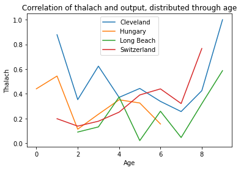

```python
import matplotlib.pyplot as plt

#Line Plot
ax =correlations.plot.line(title = 'Correlation of thalach and output, distributed through age' )
ax.set_xlabel("Age")
ax.set_ylabel("Thalach")
```

### Scatter plot

In this scatter plot we can observe the different aglomerations of thalach values for the different ages and segmented by groups

```
No artists with labels found to put in legend.  Note that artists whose label start with an underscore are ignored when legend() is called with no argument.
```

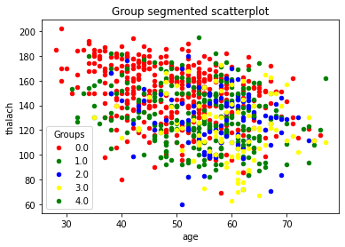

```python
#Scatter plot
groups = C.groupby('num')
colors = {0:'red', 1:'green', 2:'blue', 3:'yellow', 4: 'green'}
fig, ax = plt.subplots()
ax.margins(0.05) # Optional, just adds 5% padding to the autoscaling
ax.legend(title ='Groups')
for name, group in groups:
    group.plot(ax=ax, kind = 'scatter',x = 'age',y ='thalach',label=str(name), color = colors[name], title ='Group segmented scatterplot')
```

### Barplot

We will need the number of people in each age group and the age representing each bin in order to construct a bar plot of the age distribution

```python
#labs or labels is the age groups

bins = p.cut(x=C['age'], bins=np.linspace(26,80,11), labels=labs)
C.insert(len(C.columns),'Bins',bins)
```

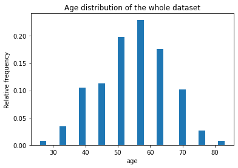

```python
x = np.round(labs*1.89+25,0)
gr=C.groupby('Bins')
frequency = []
for name, group in gr:
    frequency.append(group.shape[0])
frequency[:] = [x / C.shape[0] for x in frequency]
width = 2
plt.bar(x,frequency, width)
plt.xlabel('age')
plt.ylabel("Relative frequency")
plt.title("Age distribution of the whole dataset")
```

### Boxplot from seaborn package

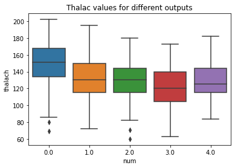

```python
#Seaborn boxplot
import seaborn as sns
ax = sns.boxplot(x="num", y='thalach', data=C).set_title("Thalac values for different outputs")
```

In the graph above we have related the values of the patients' thalach parameter with its cardiac output "diagnostic".